# Assignment-2

Author

Emma Longo

```r
library(magrittr)
library(tidyverse)
library(data.table)
library(dtplyr)
library(dplyr)
library(ggplot2)
library(tidyr)
library(leaflet)
```

# **Assignment 02 - Data Viz and Wrangling**

## **Data Wrangling**

You will need to download two datasets from https://github.com/USCbiostats/data-science-data. The [individual](https://raw.githubusercontent.com/USCbiostats/data-science-data/master/01_chs/chs_individual.csv) and [regional](https://raw.githubusercontent.com/USCbiostats/data-science-data/master/01_chs/chs_regional.csv) CHS datasets in `01_chs`. The individual data includes personal and health characteristics of children in 12 communities across Southern California. The regional data include air quality measurements at the community level. Once downloaded, you can merge these datasets using the location variable. Once combined, you will need to do the following:

```r
chs_individual <- read_csv("https://raw.githubusercontent.com/USCbiostats/data-science-data/master/01_chs/chs_individual.csv")
chs_regional <- read_csv("https://raw.githubusercontent.com/USCbiostats/data-science-data/master/01_chs/chs_regional.csv")
chs <- merge(
 x = chs_individual,
 y = chs_regional,
 by = "townname")

print(chs)
```

[output not shown]

[output cut: 7191 more lines]

1. After merging the data, make sure you don’t have any duplicates by counting the number of rows. Make sure it matches.

   In the case of missing values, impute data using the average amongst individuals with the same values for the “male” and “hispanic” variables. For categorical variables, take the mode. If you are interested (and feel adventurous) in the theme of Data Imputation, take a look at this paper on “Multiple Imputation” using the Amelia R package [here](https://gking.harvard.edu/files/gking/files/amelia_jss.pdf).

```r
chs %>%
  group_by(male, hispanic) %>%
  mutate_if(is.numeric, function(x) ifelse(is.na(x), mean(x, na.rm = TRUE), x))
```

```
`mutate_if()` ignored the following grouping variables:
• Columns `male`, `hispanic`
```

```
# A tibble: 1,200 × 49
# Groups:   male, hispanic [4]
   townname   sid  male race  hispanic agepft height weight   bmi asthma
   <chr>    <dbl> <dbl> <chr>    <dbl>  <dbl>  <dbl>  <dbl> <dbl>  <dbl>
 1 Alpine     841     1 W            1  10.5     150     78  15.8  0
 2 Alpine     835     0 W            0  10.1     143     69  15.3  0
 3 Alpine     838     0 O            1   9.49    133     62  15.9  0
 4 Alpine     840     0 W            0   9.97    146     78  16.6  0
 5 Alpine     865     0 W            0  10.0     162    140  24.2  1
 6 Alpine     867     0 W            1   9.96    141     94  21.5  0
 7 Alpine     842     1 M            1   9.49    139     65  15.3  0
 8 Alpine     839     0 M            1  10.1     142     86  19.4  0
 9 Alpine     844     1 W            1  10.5     143     65  14.4  0.160
10 Alpine     847     1 M            0   9.90    137     69  16.7  0
# ℹ 1,190 more rows
# ℹ 39 more variables: active_asthma <dbl>, father_asthma <dbl>,
#   mother_asthma <dbl>, wheeze <dbl>, hayfever <dbl>, allergy <dbl>,
#   educ_parent <dbl>, smoke <dbl>, pets <dbl>, gasstove <dbl>, fev <dbl>,
#   fvc <dbl>, mmef <dbl>, pm25_mass <dbl>, pm25_so4 <dbl>, pm25_no3 <dbl>,
#   pm25_nh4 <dbl>, pm25_oc <dbl>, pm25_ec <dbl>, pm25_om <dbl>, pm10_oc <dbl>,
#   pm10_ec <dbl>, pm10_tc <dbl>, formic <dbl>, acetic <dbl>, hcl <dbl>, …
```

```r
chs %>%
  group_by(male, hispanic) %>%
  mutate_if(is.factor, function(x) ifelse(is.na(x), mode(x), x))
```

```
`mutate_if()` ignored the following grouping variables:
• Columns `male`, `hispanic`
```

```
# A tibble: 1,200 × 49
# Groups:   male, hispanic [4]
   townname   sid  male race  hispanic agepft height weight   bmi asthma
   <chr>    <dbl> <dbl> <chr>    <dbl>  <dbl>  <dbl>  <dbl> <dbl>  <dbl>
 1 Alpine     841     1 W            1  10.5     150     78  15.8      0
 2 Alpine     835     0 W            0  10.1     143     69  15.3      0
 3 Alpine     838     0 O            1   9.49    133     62  15.9      0
 4 Alpine     840     0 W            0   9.97    146     78  16.6      0
 5 Alpine     865     0 W            0  10.0     162    140  24.2      1
 6 Alpine     867     0 W            1   9.96    141     94  21.5      0
 7 Alpine     842     1 M            1   9.49    139     65  15.3      0
 8 Alpine     839     0 M            1  10.1     142     86  19.4      0
 9 Alpine     844     1 W            1  10.5     143     65  14.4     NA
10 Alpine     847     1 M            0   9.90    137     69  16.7      0
# ℹ 1,190 more rows
# ℹ 39 more variables: active_asthma <dbl>, father_asthma <dbl>,
#   mother_asthma <dbl>, wheeze <dbl>, hayfever <dbl>, allergy <dbl>,
#   educ_parent <dbl>, smoke <dbl>, pets <dbl>, gasstove <dbl>, fev <dbl>,
#   fvc <dbl>, mmef <dbl>, pm25_mass <dbl>, pm25_so4 <dbl>, pm25_no3 <dbl>,
#   pm25_nh4 <dbl>, pm25_oc <dbl>, pm25_ec <dbl>, pm25_om <dbl>, pm10_oc <dbl>,
#   pm10_ec <dbl>, pm10_tc <dbl>, formic <dbl>, acetic <dbl>, hcl <dbl>, …
```

```r
mode <- function(x) {
  ux <- unique(x)
  ux[which.max(tabulate(match(x, ux)))]}
```

2. Create a new categorical variable named “obesity_level” using the BMI measurement (underweight BMI<14; normal BMI 14-22; overweight BMI 22-24; obese BMI>24). To make sure the variable is rightly coded, create a summary table that contains the minimum BMI, maximum BMI, and the total number of observations per category.

```r
chs <- chs %>%
    mutate(obesity_level = case_when(
    bmi < 14 ~ "underweight",
    bmi >= 14 & bmi <= 22 ~ "normal",
    bmi > 22 & bmi <= 24 ~ "overweight",
    bmi > 24 ~ "obese"))

summary_bmi <- chs %>%
  group_by(obesity_level) %>%
  summarize(
    min_bmi = min(bmi),
    max_bmi = max(bmi),
    total_obs = n())

print(summary_bmi)
```

```
# A tibble: 5 × 4
  obesity_level min_bmi max_bmi total_obs
  <chr>           <dbl>   <dbl>     <int>
1 normal           14.0    22.0       886
2 obese            24.0    41.3       103
3 overweight       22.0    24.0        87
4 underweight      11.3    14.0        35
5 <NA>             NA      NA          89
```

3. Create another categorical variable named “smoke_gas_exposure” that summarizes “Second Hand Smoke” and “Gas Stove.” The variable should have four categories in total.

```r
chs <- chs %>%
    mutate(smoke_gas_exposure = case_when(
    smoke == 0 & gasstove == 0 ~ "no_exposure",
    smoke == 1 & gasstove == 1 ~ "smoke_only",
    smoke == 0 & gasstove == 1 ~ "gas_only",
    smoke == 1 & gasstove == 1 ~ "both_exposures"))
```

4. Create four summary tables showing the average (or proportion, if binary) and sd of “Forced expiratory volume in 1 second (ml)” (an asthma indicator) by town, sex, obesity level, and “smoke_gas_exposure.”

```r
summary_town <- chs %>%
  group_by(townname) %>%
  summarize(
    avg_fev = mean(fev, na.rm = TRUE),
    sd_fev = sd(fev,na.rm = TRUE))
print(summary_town)
```

```
# A tibble: 12 × 3
   townname      avg_fev sd_fev
   <chr>           <dbl>  <dbl>
 1 Alpine          2089.   298.
 2 Atascadero      2079.   332.
 3 Lake Elsinore   2040.   318.
 4 Lake Gregory    2092.   338.
 5 Lancaster       2003.   337.
 6 Lompoc          2038.   367.
 7 Long Beach      1984.   331.
 8 Mira Loma       1985.   337.
 9 Riverside       1986.   290.
10 San Dimas       2028.   322.
11 Santa Maria     2023.   330.
12 Upland          2027.   357.
```

```r
summary_sex <- chs %>%
  group_by(male) %>%
  summarize(
    avg_fev = mean(fev, na.rm = TRUE),
    sd_fev = sd(fev,na.rm = TRUE))
print(summary_sex)
```

```
# A tibble: 2 × 3
   male avg_fev sd_fev
  <dbl>   <dbl>  <dbl>
1     0   1959.   327.
2     1   2104.   318.
```

```r
summary_obesity_level <- chs %>%
  group_by(obesity_level) %>%
  summarize(
    avg_fev = mean(fev, na.rm = TRUE),
    sd_fev = sd(fev,na.rm = TRUE))
print(summary_obesity_level)
```

```
# A tibble: 5 × 3
  obesity_level avg_fev sd_fev
  <chr>           <dbl>  <dbl>
1 normal          1998.   309.
2 obese           2269.   326.
3 overweight      2224.   317.
4 underweight     1687.   300.
5 <NA>             NaN     NA
```

```r
summary_smoke_gas_exposure <- chs %>%
  group_by(smoke_gas_exposure) %>%
  summarize(
    avg_fev = mean(fev, na.rm = TRUE),
    sd_fev = sd(fev,na.rm = TRUE))
print(summary_smoke_gas_exposure)
```

```
# A tibble: 4 × 3
  smoke_gas_exposure avg_fev sd_fev
  <chr>                <dbl>  <dbl>
1 gas_only             2026.   328.
2 no_exposure          2060.   343.
3 smoke_only           2020.   313.
4 <NA>                 2022.   353.
```

## **Looking at the Data (EDA)**

The primary questions of interest are:

1. What is the association between BMI and FEV (forced expiratory volume)?
2. What is the association between smoke and gas exposure and FEV?
3. What is the association between PM2.5 exposure and FEV?

Follow the EDA checklist from week 3 and the previous assignment. Be sure to focus on the key variables.

- Formulate a question - done
- Read in the data - done
- Check the dimensions and headers and footers of the data

```r
dim(chs)
```

```
[1] 1200   51
```

```r
head(chs)
```

```
  townname sid male race hispanic    agepft height weight      bmi asthma
1   Alpine 841    1    W        1 10.548939    150     78 15.75758      0
2   Alpine 835    0    W        0 10.099932    143     69 15.33749      0
3   Alpine 838    0    O        1  9.486653    133     62 15.93183      0
4   Alpine 840    0    W        0  9.965777    146     78 16.63283      0
5   Alpine 865    0    W        0 10.039699    162    140 24.24797      1
6   Alpine 867    0    W        1  9.957563    141     94 21.49151      0
  active_asthma father_asthma mother_asthma wheeze hayfever allergy educ_parent
1             0             0             0      0        0       0           5
2             0             0             0      0        0       1           3
3             0             0             0      0        0       0           4
4             0             0             0      0        0       0          NA
5             1             0             0      1        0       1           3
6             0            NA             0      0        0       0           5
  smoke pets gasstove      fev      fvc     mmef pm25_mass pm25_so4 pm25_no3
```

[output cut: 27 more lines]

```r
tail(chs)
```

```
     townname  sid male race hispanic    agepft height weight      bmi asthma
1195   Upland 1866    0    O        1  9.806982    139     60 14.11559      0
1196   Upland 1867    0    M        1  9.618070    140     71 16.46568      0
1197   Upland 2033    0    M        0 10.121834    130     67 18.02044      0
1198   Upland 2031    1    W        0  9.798768    135     83 20.70084      0
1199   Upland 2032    1    W        0  9.549624    137     59 14.28855      0
1200   Upland 2053    0    W        0        NA     NA     NA       NA      0
     active_asthma father_asthma mother_asthma wheeze hayfever allergy
1195             0            NA             0      0       NA      NA
1196             0             1             0      0        0       0
1197             1             0             0      1        1       0
1198             0             0             0      1        0       1
1199             0             0             1      1        1       1
1200             0             0             0      0        0       0
     educ_parent smoke pets gasstove      fev      fvc     mmef pm25_mass
```

[output cut: 34 more lines]

- Check the variable types in the data

```r
str(chs)
```

```
'data.frame':   1200 obs. of  51 variables:
 $ townname          : chr  "Alpine" "Alpine" "Alpine" "Alpine" ...
 $ sid               : num  841 835 838 840 865 867 842 839 844 847 ...
 $ male              : num  1 0 0 0 0 0 1 0 1 1 ...
 $ race              : chr  "W" "W" "O" "W" ...
 $ hispanic          : num  1 0 1 0 0 1 1 1 1 0 ...
 $ agepft            : num  10.55 10.1 9.49 9.97 10.04 ...
 $ height            : num  150 143 133 146 162 141 139 142 143 137 ...
 $ weight            : num  78 69 62 78 140 94 65 86 65 69 ...
 $ bmi               : num  15.8 15.3 15.9 16.6 24.2 ...
 $ asthma            : num  0 0 0 0 1 0 0 0 NA 0 ...
 $ active_asthma     : num  0 0 0 0 1 0 0 0 0 0 ...
 $ father_asthma     : num  0 0 0 0 0 NA 0 0 NA 0 ...
 $ mother_asthma     : num  0 0 0 0 0 0 0 1 NA 0 ...
 $ wheeze            : num  0 0 0 0 1 0 1 1 NA 0 ...
```

[output cut: 37 more lines]

- Take a closer look at some/all of the variables
- Conduct some summary statistics to answer the initial question

```r
summary(chs$bmi)
```

```
   Min. 1st Qu.  Median    Mean 3rd Qu.    Max.    NA's
  11.30   15.78   17.48   18.50   20.35   41.27      89
```

```r
table(chs$obesity_level)
```

```
     normal       obese  overweight underweight
        886         103          87          35
```

```r
summary(chs$fev)
```

```
   Min. 1st Qu.  Median    Mean 3rd Qu.    Max.    NA's
  984.8  1809.0  2022.7  2031.3  2249.7  3323.7      95
```

```r
table(chs$smoke_gas_exposure)
```

```
   gas_only no_exposure  smoke_only
        739         214         151
```

```r
summary(chs$pm25_mass)
```

```
   Min. 1st Qu.  Median    Mean 3rd Qu.    Max.
  5.960   7.615  10.545  14.362  20.988  29.970
```

- Make exploratory graphs

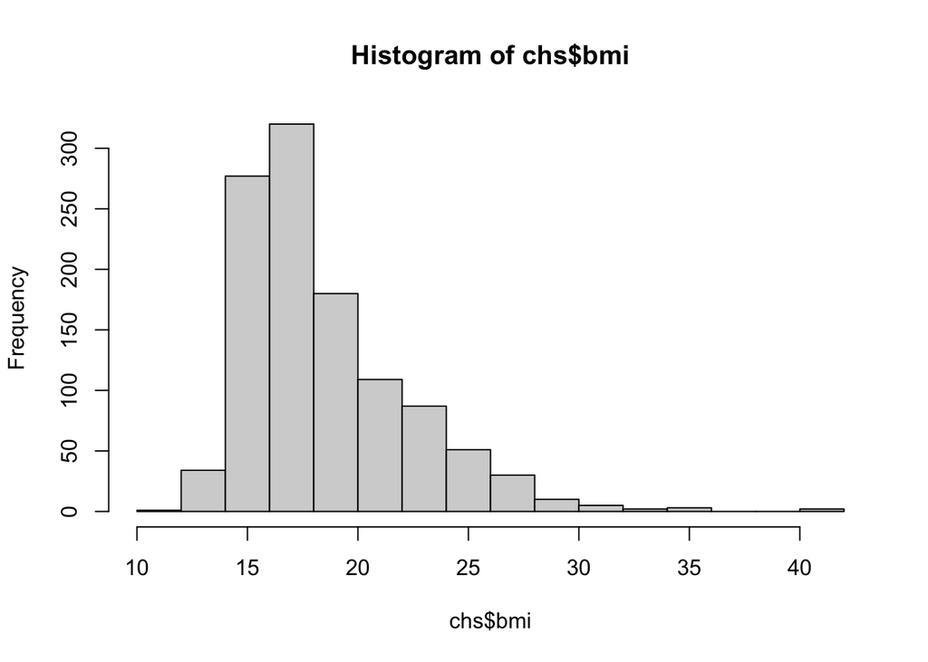

```r
hist(chs$bmi)
```

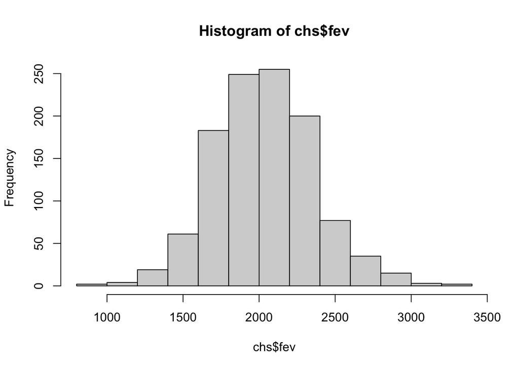

```r
hist(chs$fev)
```

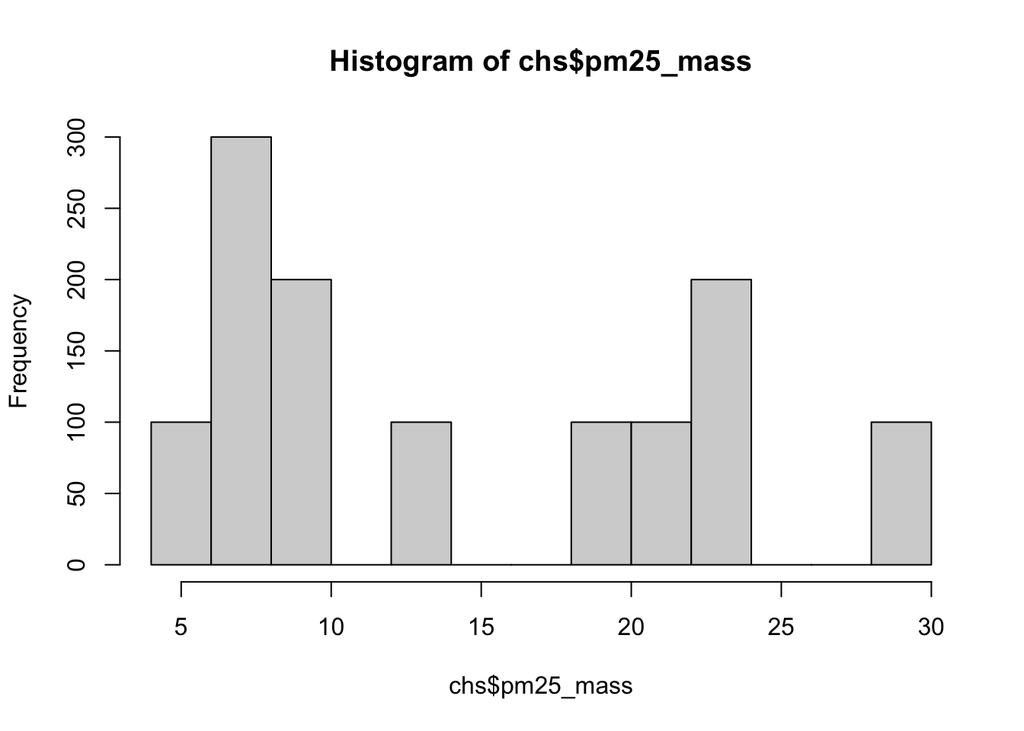

```r
hist(chs$pm25_mass)
```

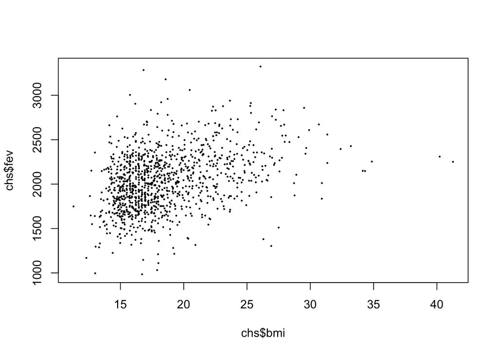

```r
#What is the association between BMI and FEV (forced expiratory volume)?
plot(chs$bmi, chs$fev, pch=10, cex=0.2)
```

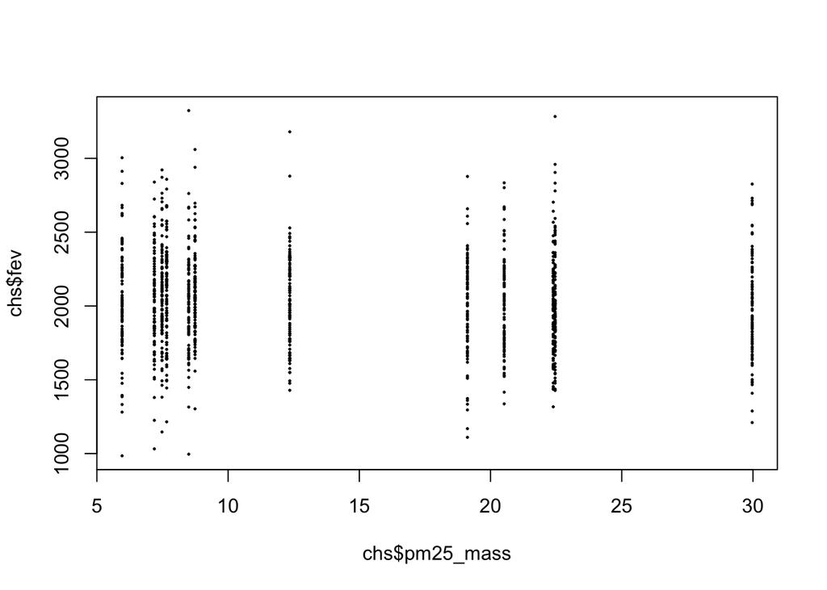

```r
#What is the association between PM2.5 exposure and FEV?
plot(chs$pm25_mass, chs$fev, pch=10, cex=0.2)
```

## **Visualization**

Create the following figures and interpret them. Be sure to include easily understandable axes, titles, and legends.

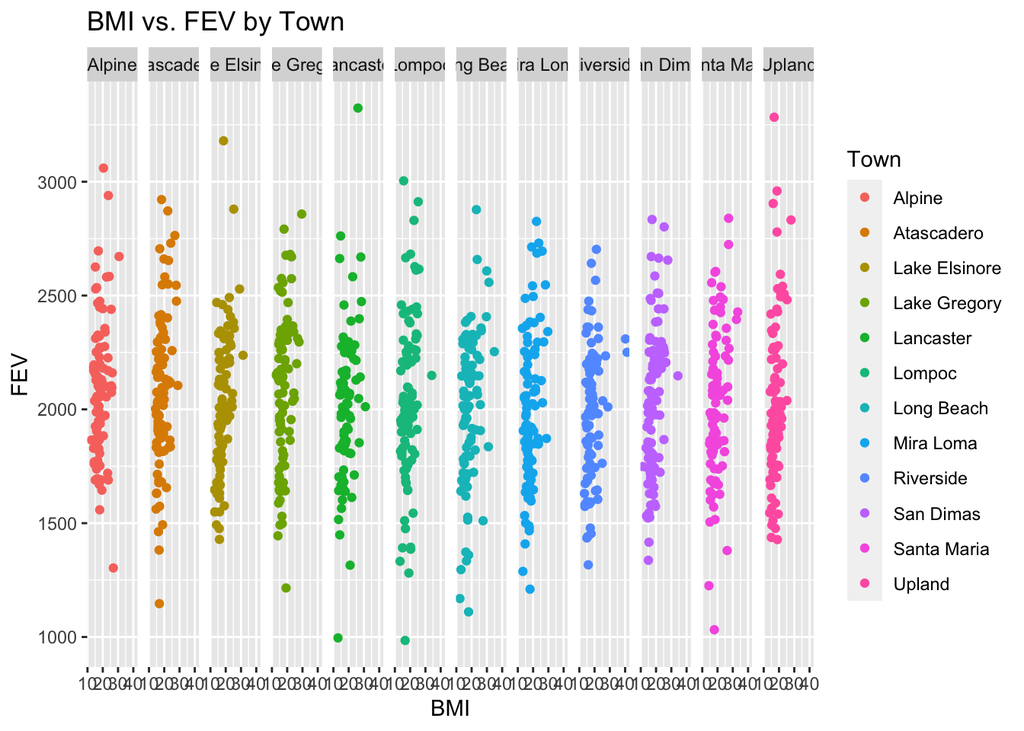

```r
ggplot(data = chs) +
  geom_point(mapping = aes(x = bmi, y = fev, color = townname)) +
  facet_wrap(~ townname, nrow = 1) +
  labs(
    title = "BMI vs. FEV by Town",
    x = "BMI",
    y = "FEV",
    color = "Town")
```

2. Stacked histograms of FEV by BMI category and FEV by smoke/gas exposure. Use different color schemes than the ggplot default.

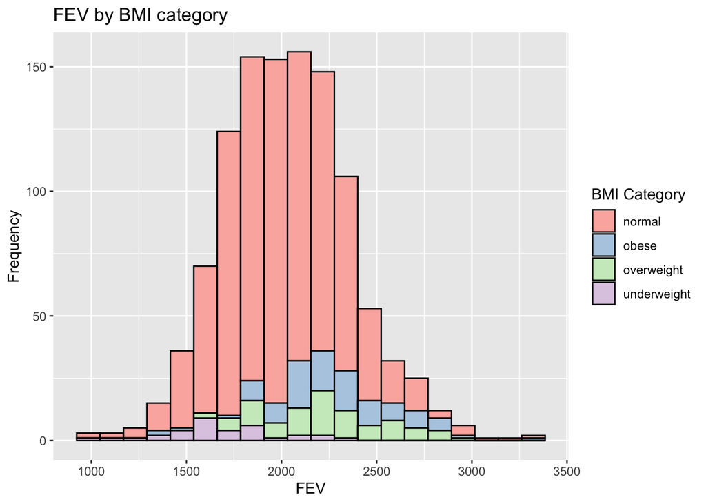

```r
ggplot(data = chs) +
  geom_histogram(mapping = aes(x = fev, fill = obesity_level), position = "stack", bins = 20, color = "black") +
  scale_fill_brewer(palette = "Pastel1") +
  labs(
    title = "FEV by BMI category",
    x = "FEV",
    y = "Frequency",
    fill = "BMI Category")
```

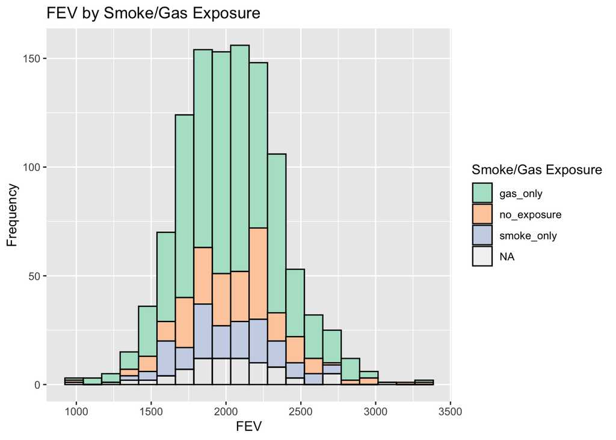

```r
ggplot(data = chs) +
  geom_histogram(mapping = aes(x = fev, fill = smoke_gas_exposure), position = "stack", bins = 20, color = "black") +
  scale_fill_brewer(palette = "Pastel2") +
  labs(
    title = "FEV by Smoke/Gas Exposure",
    x = "FEV",
    y = "Frequency",
    fill = "Smoke/Gas Exposure")
```

3. Barchart of BMI by smoke/gas exposure.

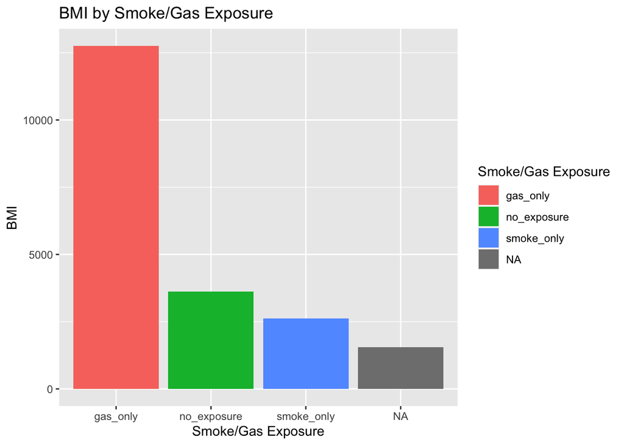

```r
ggplot(data = chs) +
  geom_bar(stat = "identity", mapping = aes(x = smoke_gas_exposure, y = bmi, fill = smoke_gas_exposure)) +
  labs(
    title = "BMI by Smoke/Gas Exposure",
    x = "Smoke/Gas Exposure",
    y = "BMI",
    fill = "Smoke/Gas Exposure")
```

4. Statistical summary graphs of FEV by BMI and FEV by smoke/gas exposure category.

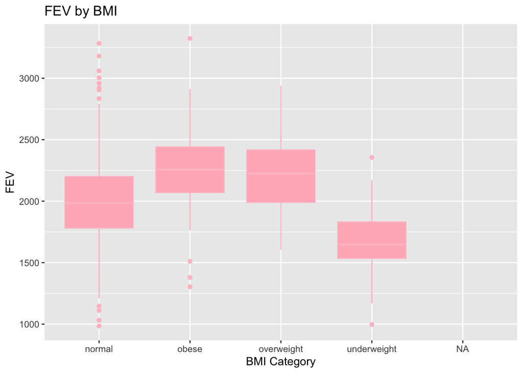

```r
ggplot(chs, aes(x = obesity_level, y = fev)) +
  geom_boxplot(fill = "lightpink", color = "pink") +
  labs(
    title = "FEV by BMI",
    x = "BMI Category",
    y = "FEV")
```

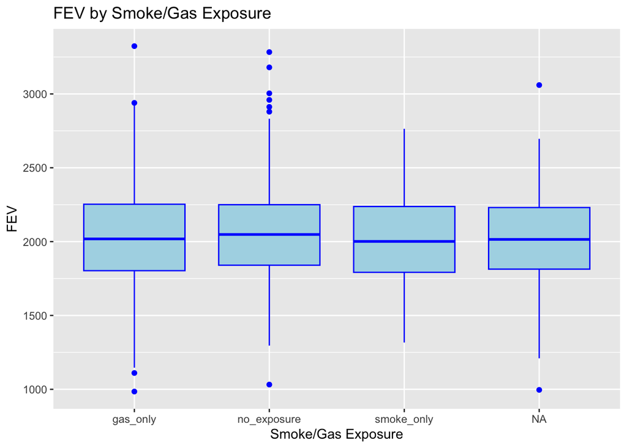

```r
ggplot(chs, aes(x = smoke_gas_exposure, y = fev)) +
  geom_boxplot(fill = "lightblue", color = "blue") +
  labs(
    title = "FEV by Smoke/Gas Exposure",
    x = "Smoke/Gas Exposure",
    y = "FEV")
```

5. A leaflet map showing the concentrations of PM2.5 mass in each of the CHS communities.

```r
leaflet(chs) %>%
  addProviderTiles('CartoDB.Positron') %>%
  addCircles(
    lat = ~lat,
    lng = ~lon,
    color = "black",
    radius = 400,
    opacity = 1,
    fillOpacity = 1,)
```

[interactive chart not shown]

6. Choose a visualization to examine whether PM2.5 mass is associated with FEV.

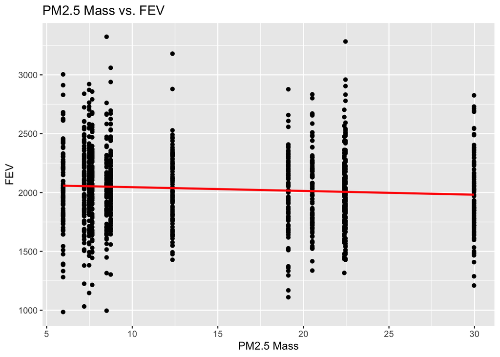

```r
ggplot(data = chs) +
  geom_point(mapping = aes(x = pm25_mass, y = fev)) +
  geom_smooth(mapping = aes(x = pm25_mass, y = fev), method = "lm", se = FALSE, color = "red") +
  labs(
    title = "PM2.5 Mass vs. FEV",
    x = "PM2.5 Mass",
    y = "FEV")
```